# Analysis

## Research questions

*Main research question:*

How do news media report about cancer screening in the Netherlands from 2010 to 2022?

*Subquestions:*

1. What are the volume, characteristics and content of news media reports about cancer screening?
2. To what extent and how does the media coverage change over time?
3. How is information about cancer screening in news media reports contextualized?
4. To what extent and how does the media coverage differ between types of cancer screening?

# Q1: Volume, characteristics and content

## Volume (N and %)

NB: the number of screening articles is similar to the entire dataset that will be analyzed below (duplicates included). For the articles about cancer, we took the “cancer” part of the search string and registered the number of articles about cancer per year. The percentage reflects the total amount of articles about screening divided by the total number of news articles about the specific cancer type.

**Total amount of news articles**

News about *screening* and *cancer* from 2010 to 2022

| cancer_type | screening | cancer | percentage |
| --- | --- | --- | --- |
| cervical | 1991 | 8637 | 23.05 |
| breast | 5227 | 45528 | 11.48 |
| colon | 2895 | 18946 | 15.28 |
| prostate | 1079 | 14897 | 7.24 |
| lung | 796 | 24215 | 3.29 |

## Characteristics (N and %)

### Article characteristics

#### Inclusion

| inclusion | n | perc |
| --- | --- | --- |
| Exclusie | 249 | 26.95 |
| Inclusie | 675 | 73.05 |

#### Average word count

##### Total

| m | sd |
| --- | --- |
| 812.48 | 6076.42 |

##### Inclusion vs. exclusion

No significant difference in the number of words for in and excluded articles.

|  | m | sd |
| --- | --- | --- |
| Exclusie | 1606.61 | 11640.43 |
| Inclusie | 519.53 | 622.23 |

```
##
##  Welch Two Sample t-test
##
## data:  df$word_count by df$inclusion
## t = 1.4729, df = 248.52, p-value = 0.142
## alternative hypothesis: true difference in means between group Exclusie and group Inclusie is not equal to 0
## 95 percent confidence interval:
##  -366.5844 2540.7585
## sample estimates:
## mean in group Exclusie mean in group Inclusie
##              1606.6145               519.5274
```

#### Geographical reach

|  | n | perc |
| --- | --- | --- |
| regional | 279 | 41.33 |
| national | 218 | 32.30 |
| local | 178 | 26.37 |

#### News genre

|  | n | perc |
| --- | --- | --- |
| Nieuwsbericht | 441 | 65.33 |
| Interview en persoonlijk verhaal | 146 | 21.63 |
| Columns en opiniestukken | 47 | 6.96 |
| Achtergrondartikel | 23 | 3.41 |
| Ingezonden brieven | 9 | 1.33 |
| Overig | 9 | 1.33 |

#### News content

|  | n | perc |
| --- | --- | --- |
| Gezondheid en zorg | 314 | 46.52 |
| Beleid | 93 | 13.78 |
| Wetenschap | 88 | 13.04 |
| Cultuur, media, sport en entertainment | 71 | 10.52 |
| COVID-19 | 52 | 7.70 |
| Technologie en economie | 33 | 4.89 |
| Overig | 24 | 3.56 |

### Content characteristics

#### General

##### Cancer type

|  | n | perc |
| --- | --- | --- |
| Borstkanker | 329 | 48.74 |
| Darmkanker | 150 | 22.22 |
| Baarmoederhalskanker | 82 | 12.15 |
| Algemeen | 76 | 11.26 |
| Prostaatkanker | 28 | 4.15 |
| Longkanker | 10 | 1.48 |

##### Main or side issue

|  | n | perc |
| --- | --- | --- |
| Bijzaak | 172 | 25.48 |
| Hoofdzaak | 503 | 74.52 |

##### Cancer topic

|  | n | perc |
| --- | --- | --- |
| Kanker | 172 | 25.48 |
| Kankerscreening: bestaande methoden | 464 | 68.74 |
| Kankerscreening: innovatieve methoden | 39 | 5.78 |

##### Cancer topic & main/side issue

|  | Bijzaak n | Bijzaak % | Hoofdzaak n | Hoofdzaak % |
| --- | --- | --- | --- | --- |
| Kanker | 42 | 24.42 | 130 | 25.84 |
| Kankerscreening: bestaande methoden | 128 | 74.42 | 336 | 66.80 |
| Kankerscreening: innovatieve methoden | 2 | 1.16 | 37 | 7.36 |

##### Preventive measures

|  | n | perc |
| --- | --- | --- |
| Screening alternatives | 53 | 7.85 |
| Lifestyle | 52 | 7.70 |
| Vaccination | 17 | 2.52 |
| Surgery | 17 | 2.52 |

##### Sources

|  | n | perc |
| --- | --- | --- |
| Health care professional | 175 | 25.93 |
| Science | 160 | 23.70 |
| Health organization | 159 | 23.56 |
| Personal | 142 | 21.04 |
| Politics | 69 | 10.22 |
| Other | 61 | 9.04 |

#### Framing

##### Effectiveness frame

###### All

|  | n | perc |
| --- | --- | --- |
| Expliciet effectief | 221 | 32.74 |
| Impliciet effectief | 175 | 25.93 |
| Neutraal | 153 | 22.67 |
| Effectiviteit betwist | 126 | 18.67 |

###### Current

Lung and prostate excluded

|  | n | perc |
| --- | --- | --- |
| Expliciet effectief | 191 | 34.05 |
| Neutraal | 141 | 25.13 |
| Impliciet effectief | 137 | 24.42 |
| Effectiviteit betwist | 92 | 16.40 |

##### Risk frame

###### All

|  | n | perc |
| --- | --- | --- |
| Neutral | 538 | 79.70 |
| High | 115 | 17.04 |
| Low | 22 | 3.26 |

###### Current

Lung and prostate excluded

|  | n | perc |
| --- | --- | --- |
| Neutral | 460 | 82.00 |
| High | 82 | 14.62 |
| Low | 19 | 3.39 |

##### Consequence frame

###### All

|  | n | perc |
| --- | --- | --- |
| Neutral | 340 | 50.37 |
| Severe | 320 | 47.41 |
| Not severe | 15 | 2.22 |

###### Current

Lung and prostate excluded

|  | n | perc |
| --- | --- | --- |
| Neutral | 300 | 53.48 |
| Severe | 251 | 44.74 |
| Not severe | 10 | 1.78 |

##### Pros and cons

|  | n | perc |
| --- | --- | --- |
| Current: pro | 467 | 69.19 |
| Current: con | 433 | 64.15 |
| Innovation: pro | 146 | 21.63 |
| Innovation: con | 136 | 20.15 |

# Q2: Changes over time

## Volume of news over time

### All articles

NB: rolling mean set at 3, i.e. taking into account one month/quarter before and after the point of measurement.

#### Per quarter

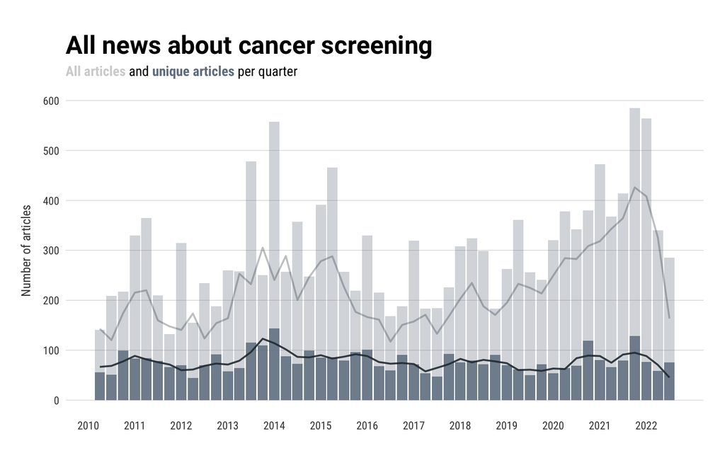

#### Per month

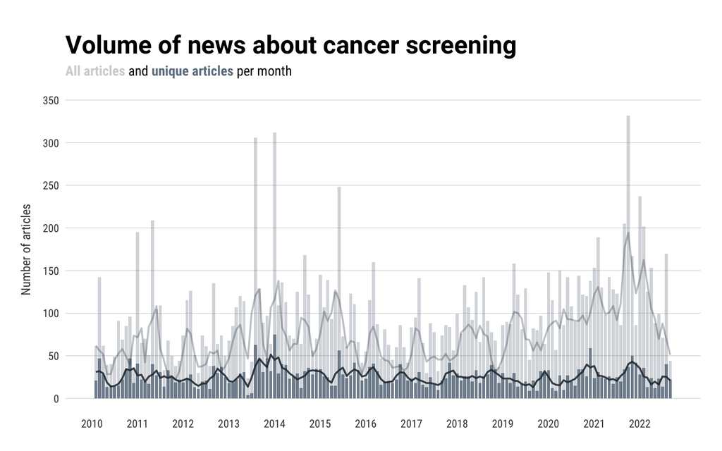

### Cervical cancer

#### Per quarter

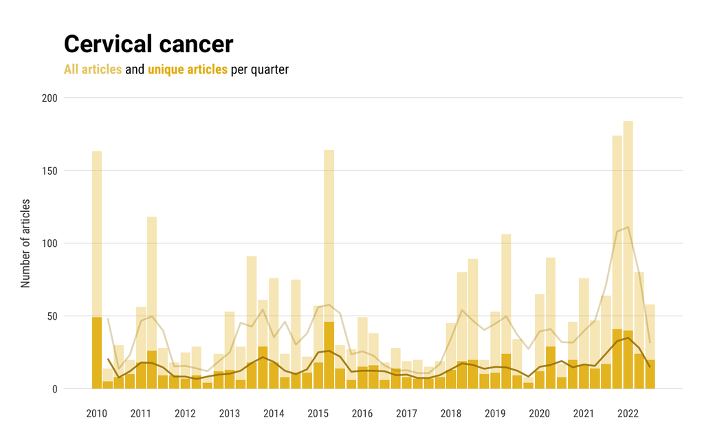

#### Per month - dupl incl.

[figure not shown]

#### Per month - single docs

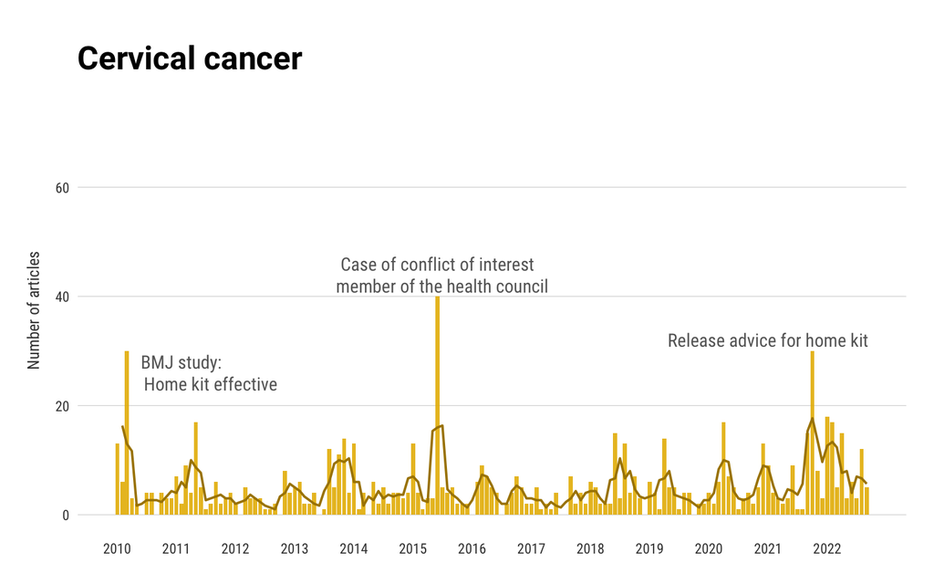

#### Vs. cancer articles

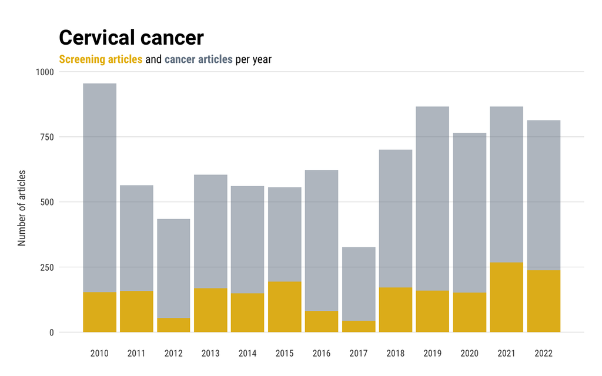

### Breast cancer

#### Per quarter

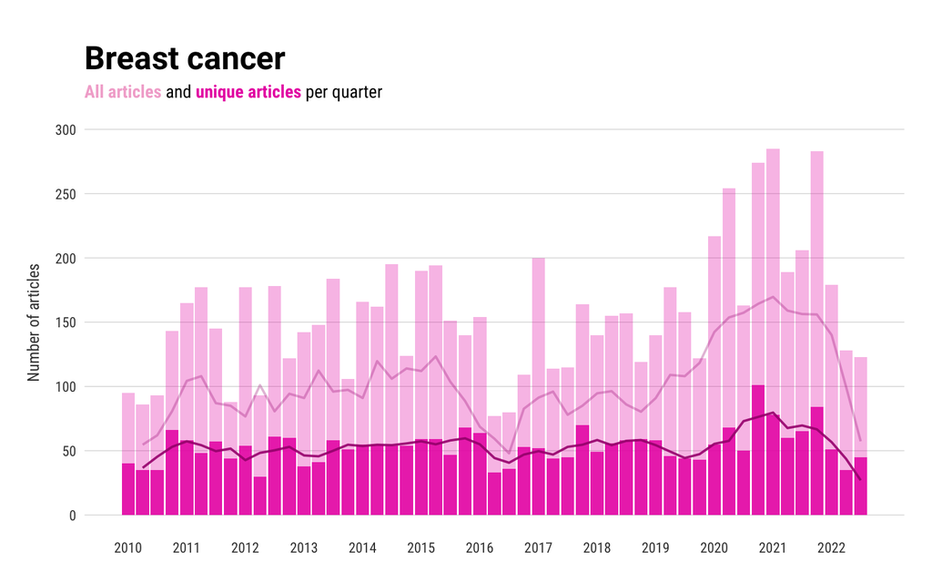

#### Per month - dupl incl

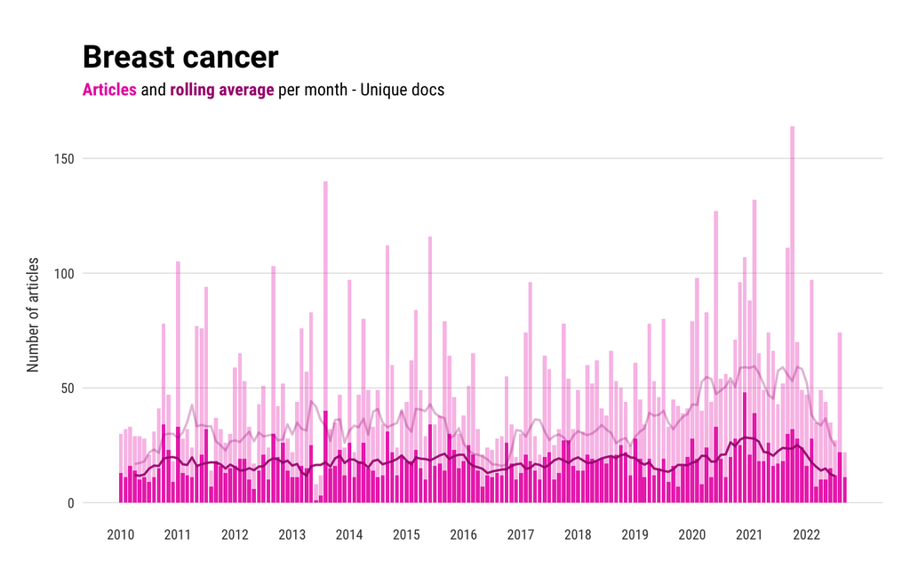

#### Per month - single docs

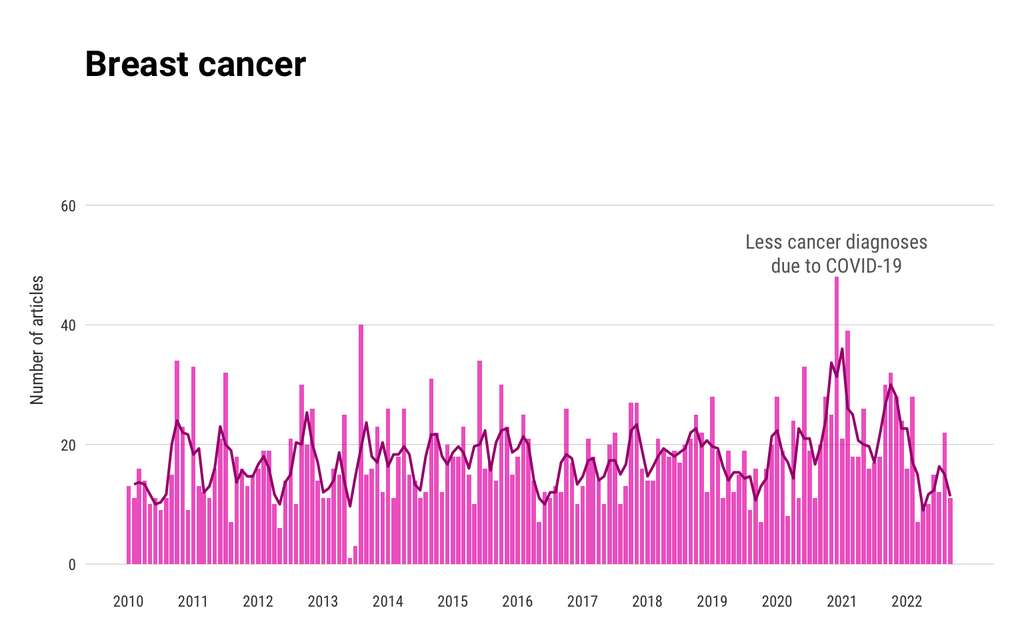

#### Vs. cancer articles

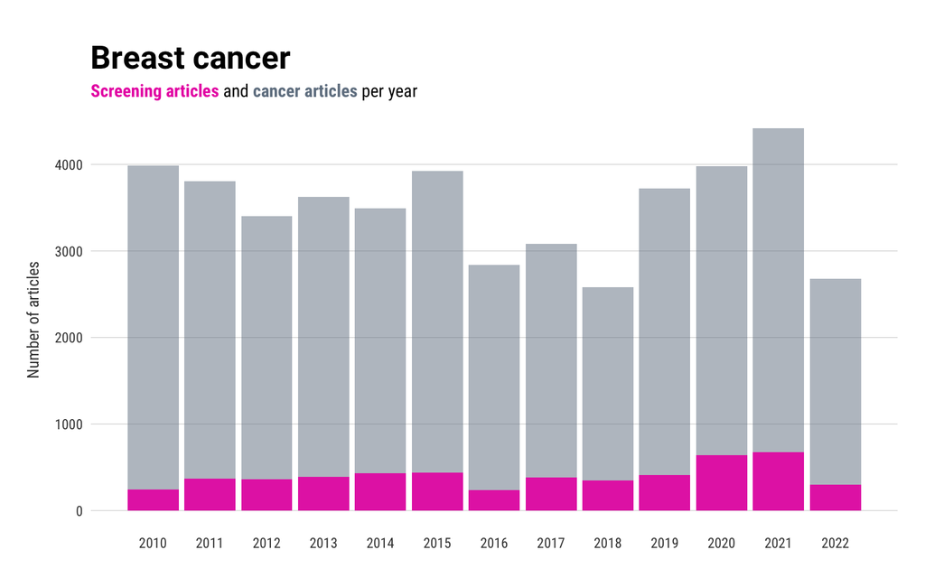

### Colon cancer

#### Per quarter

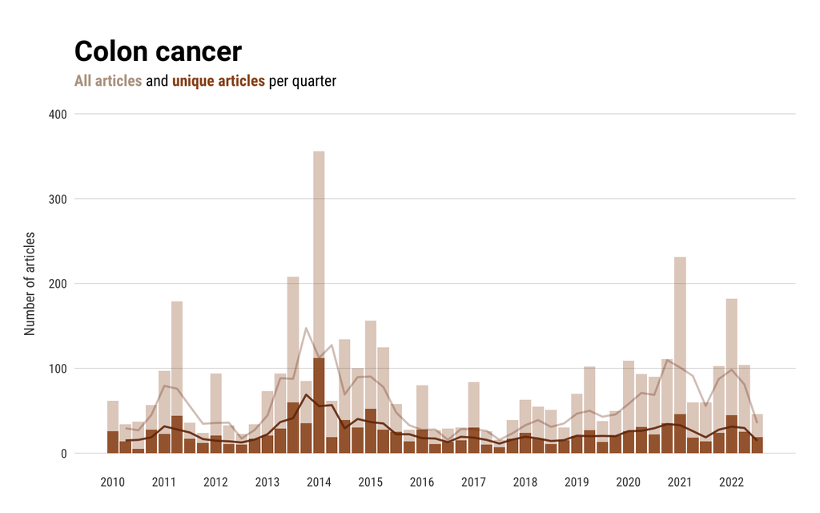

#### Per month - dupl incl

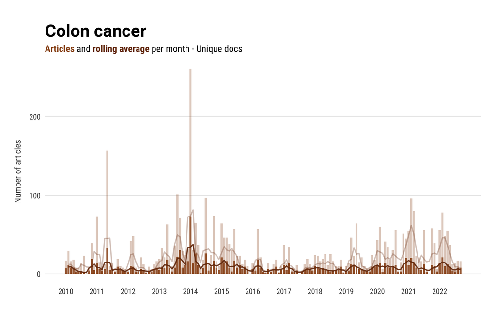

#### Per month - single docs

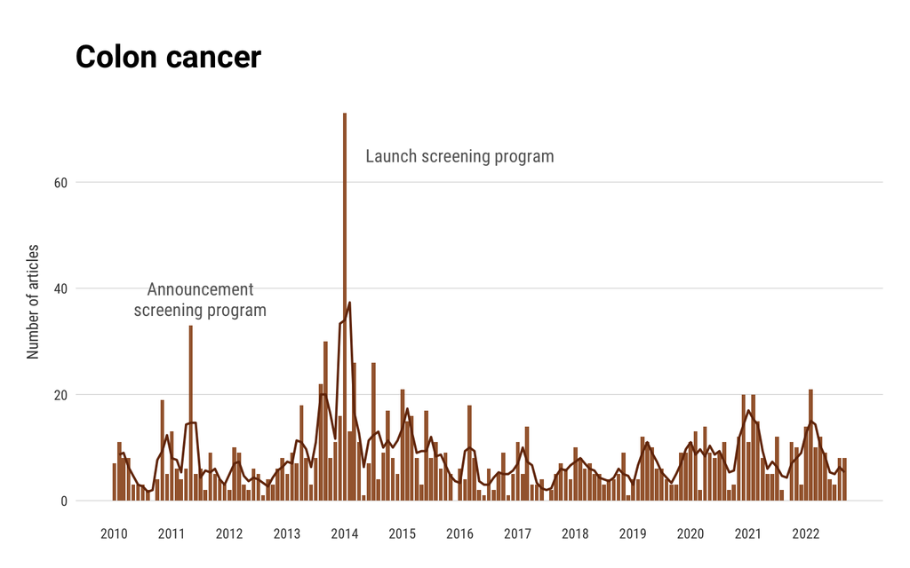

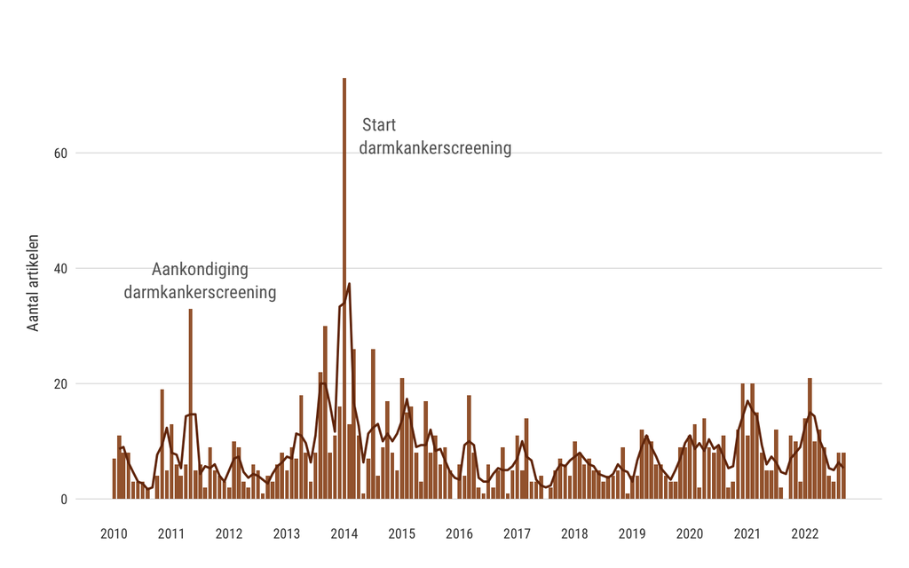

#### Vs. cancer articles

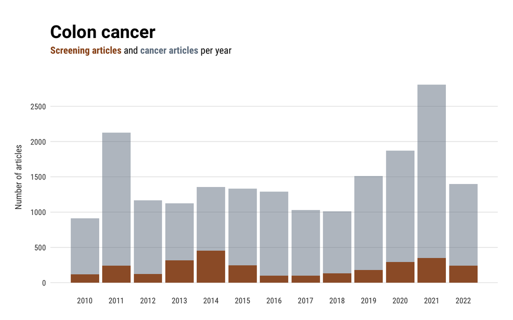

### Lung cancer

#### Per quarter

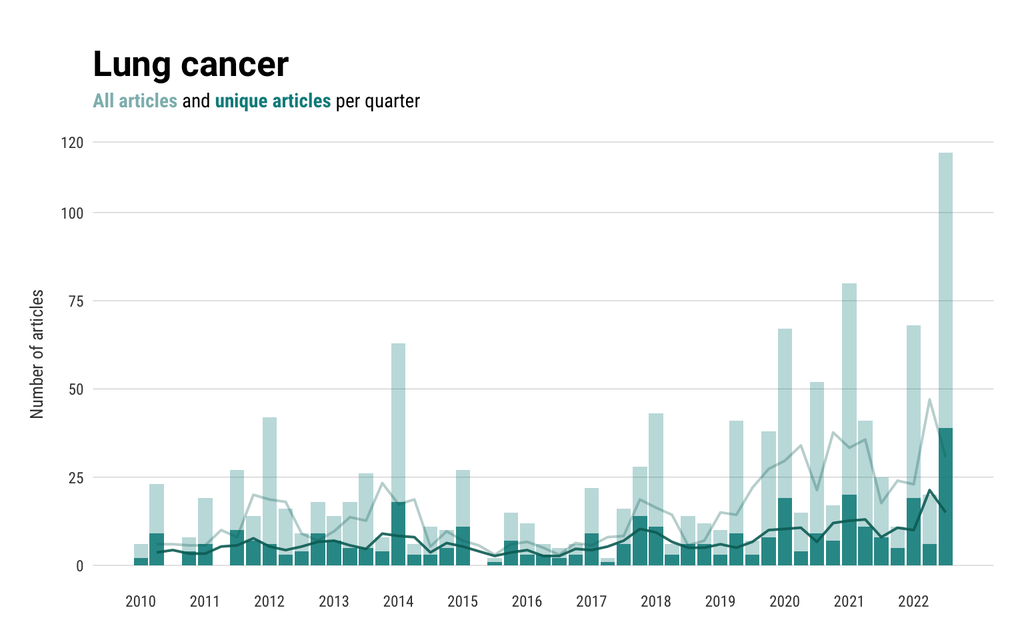

#### Per month - dupl incl

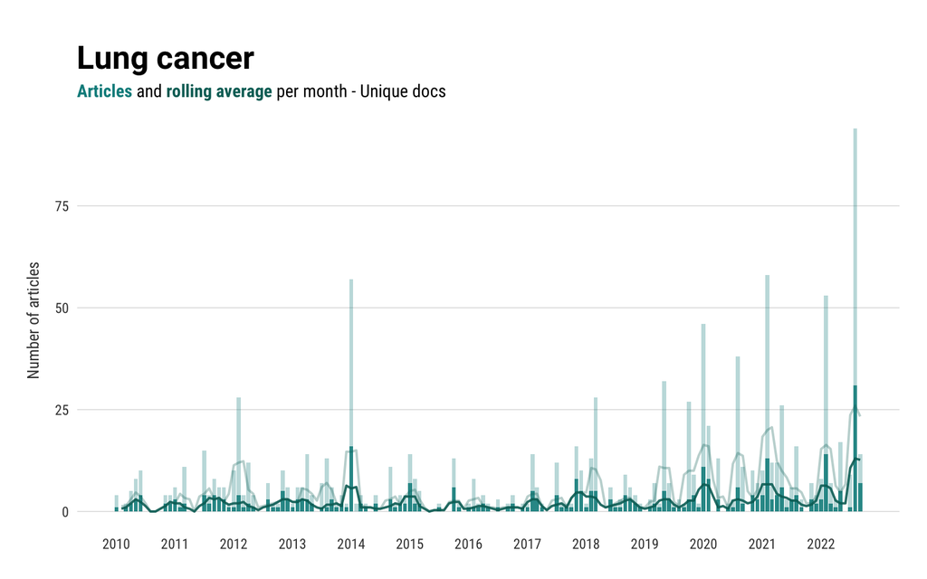

#### Per month - single docs

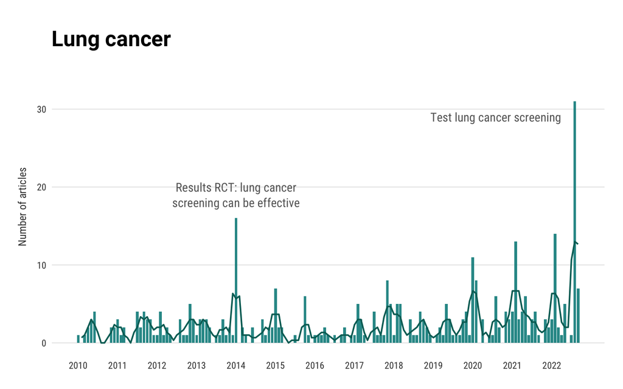

#### Vs. cancer articles

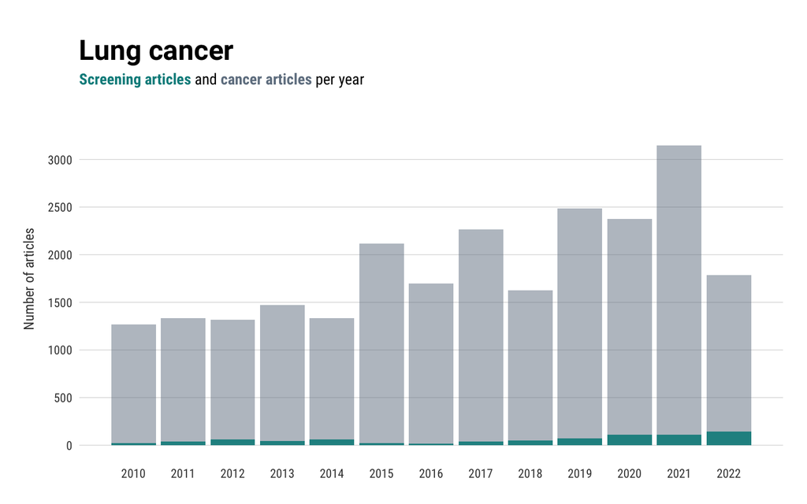

### Prostate cancer

#### Per quarter

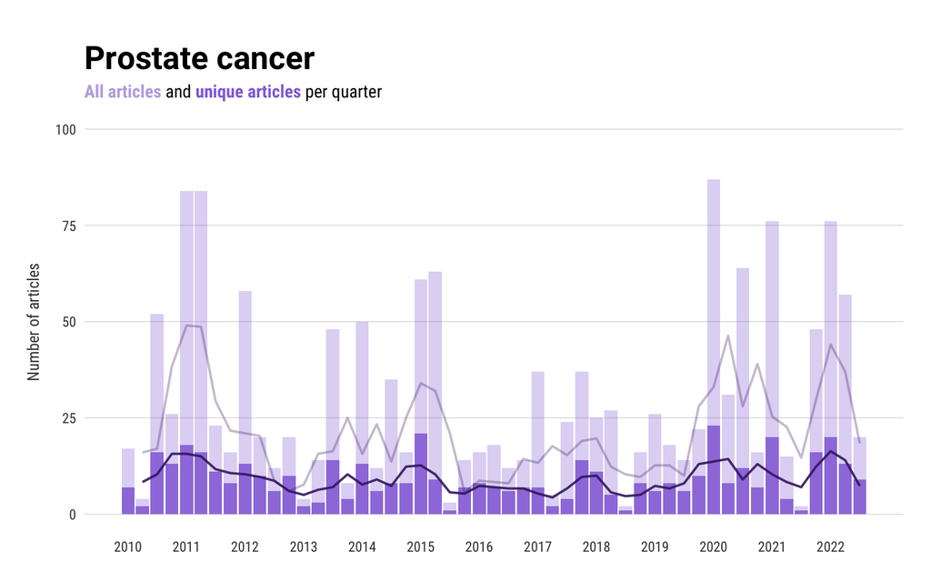

#### Per month - dupl incl

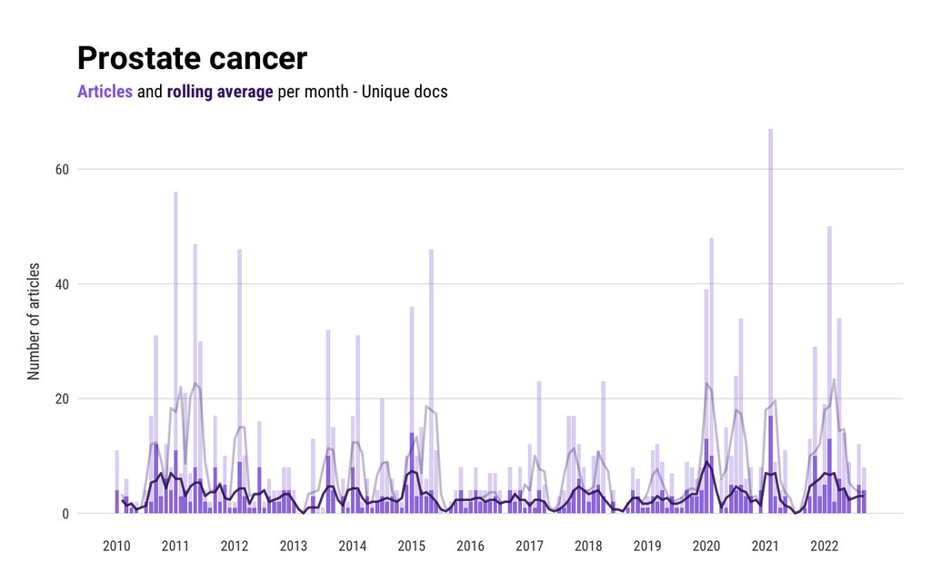

#### Per month - single docs

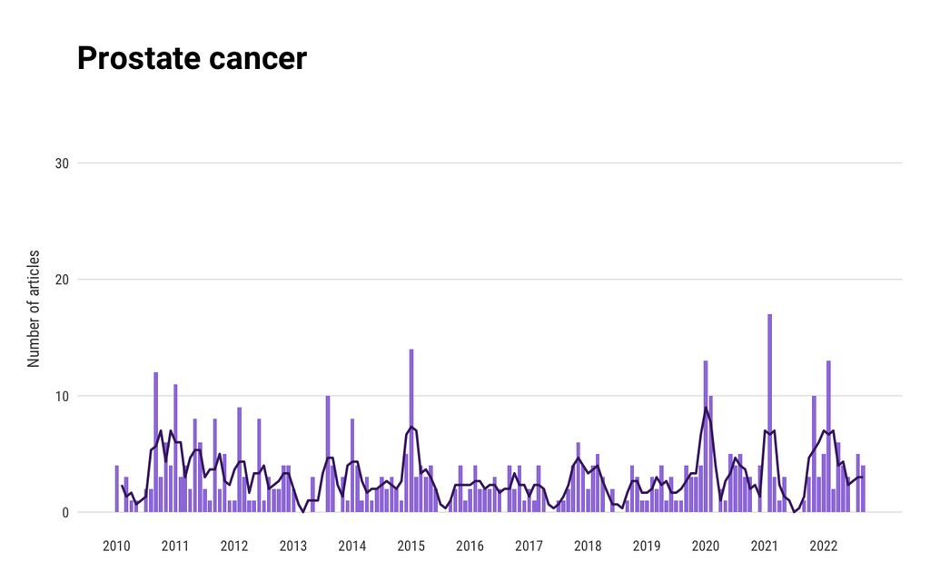

#### Vs. cancer articles

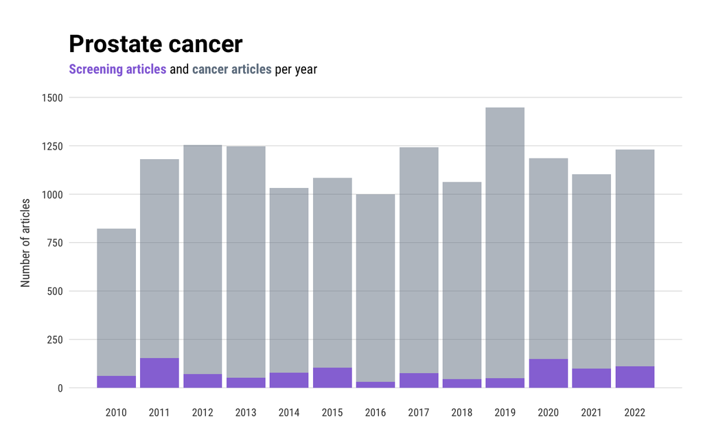

## News framing over time

All graphs display a rolling average of 3 (i.e. the average of one quarters/years preceding and following the data point)

### Effectiveness (all subcats)

#### Per year

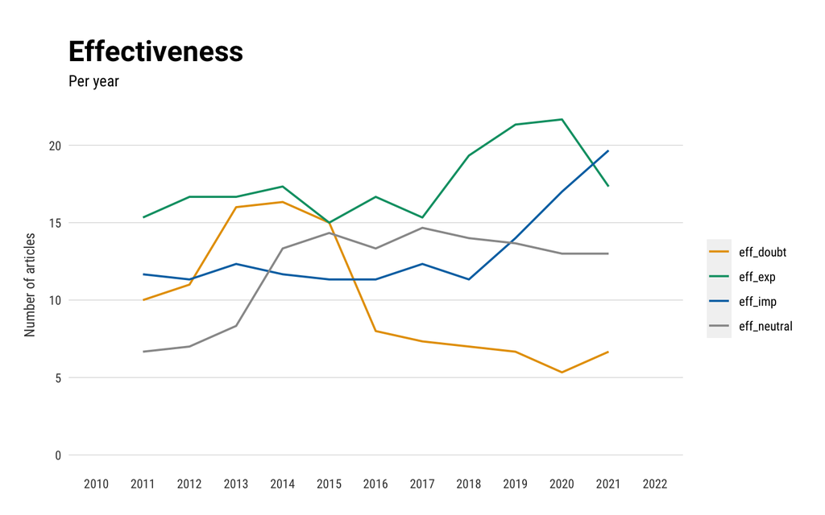

#### Per quarter

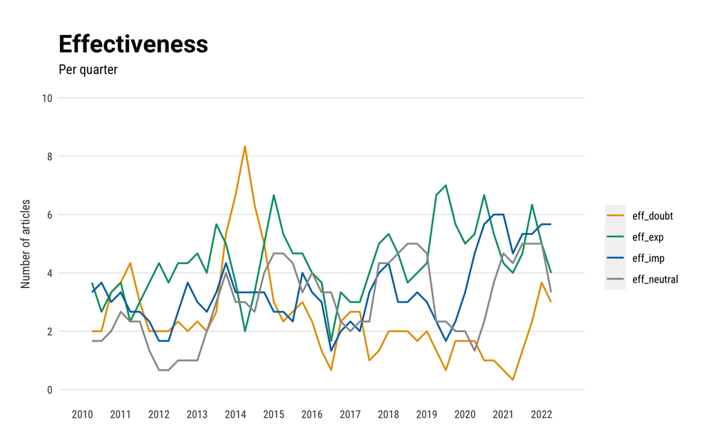

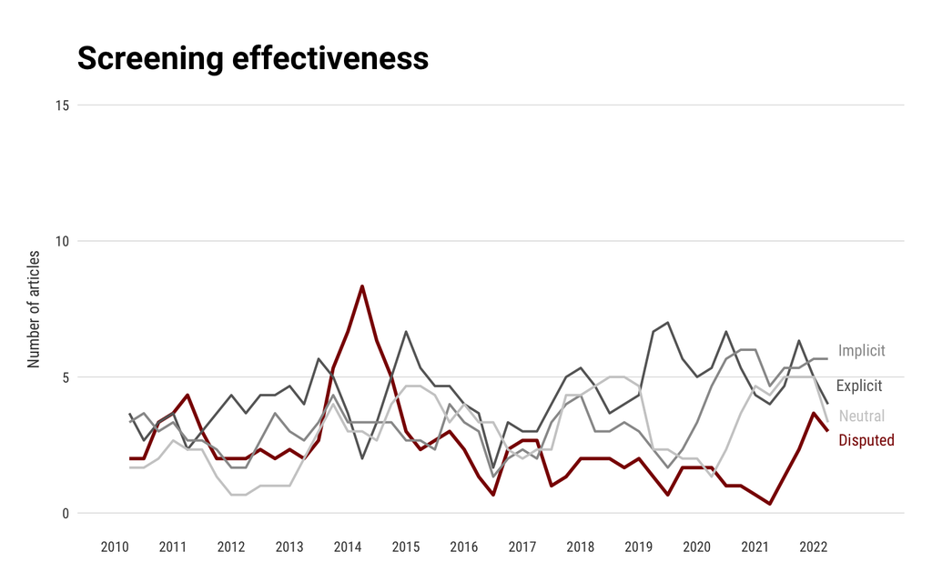

#### Per quarter - effectivess disputed

There seems to be a peek in the number of news articles that dispute the effectiveness of cancer screening surrounding the introduction of the colon cancer screening program. To check whether the peek in effectivenss disputed may be related to articles about colon cancer screening, the plot below demonstrates only articles where that were coded as ‘effectiveness disputed’, differentiated between breast, cervical and colon cancer screening.

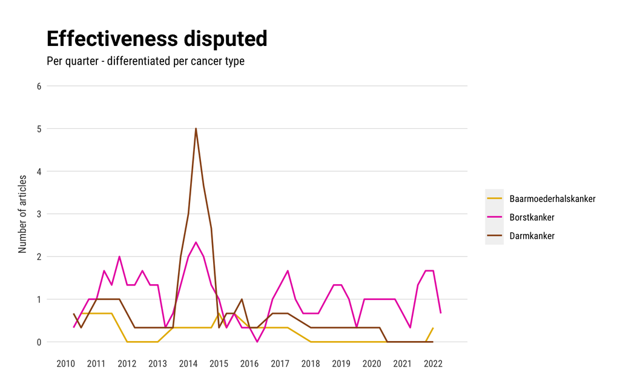

**Effectiveness disputed plot only for colon cancer** Including absolute frequencies

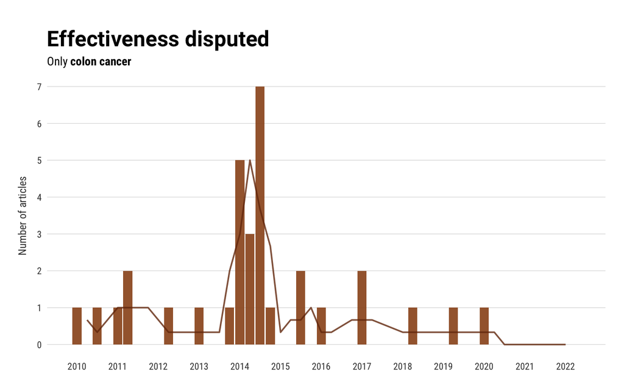

### Effectiveness (merged)

#### Per year

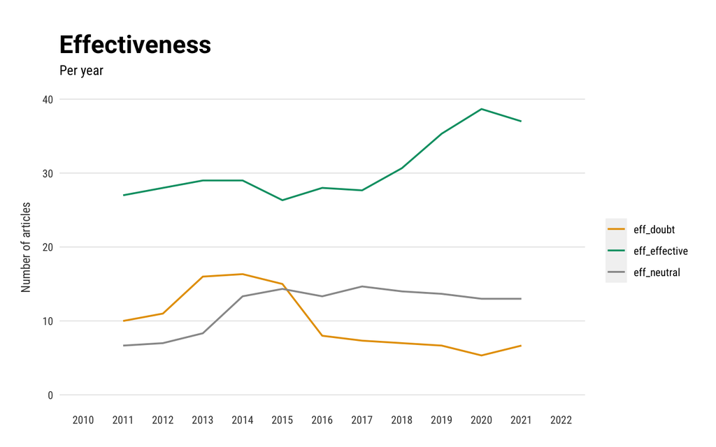

#### Per quarter

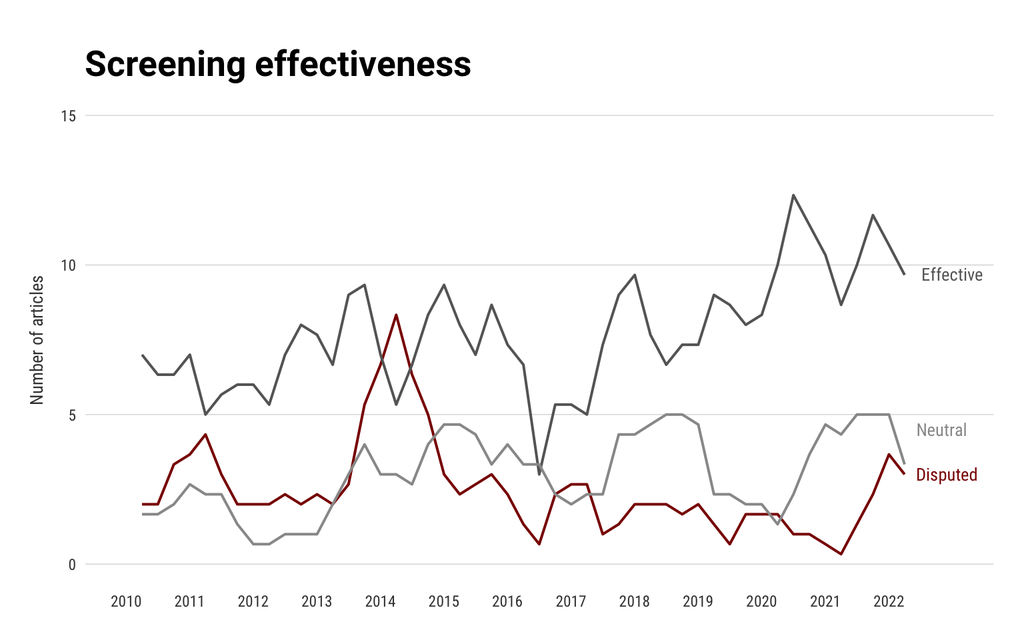

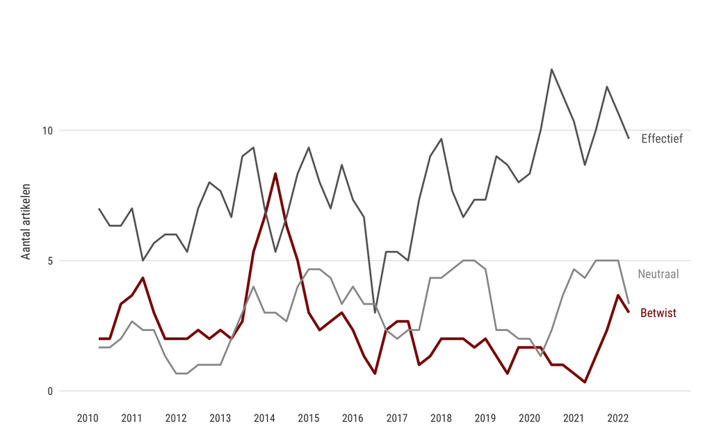